# Cross-Seed Invariance Analysis

This notebook provides interactive comparison of training runs for seed invariance analysis—answering the question: **Are detected events real, or artifacts of randomness?**

## Purpose

Events that appear consistently across runs with different random seeds indicate genuine learning dynamics; events appearing in only one seed are likely noise. This notebook computes invariance metrics at multiple levels and provides visualizations to diagnose reproducibility.

## The Invariance Stack

The analysis computes invariance at multiple levels, forming a diagnostic hierarchy:

| Level | Metric | Question |
| --- | --- | --- |
| **Signal** | Trajectory Correlation | Do the geometry curves look the same? |
| **Neighborhood** | Neighbor Coverage | Do both seeds show activity in the same neighborhoods? |
| **Peak** | IoU Jaccard | Do they select the same discrete event winners? |

### Common Pattern: "Stable Energy Landscape / Unstable Argmax"

The most typical result:

- **High trajectory correlation** (~0.91) — The underlying signal is reproducible
- **Moderate neighbor coverage** (~50%) — Events occur in the same neighborhoods
- **Low peak IoU Jaccard** (~29%) — Different discrete winners are selected

This means: *Both seeds detect the same learning dynamics, but pick different winners within matched neighborhoods due to suppression sensitivity.*

## Key Metrics Explained

### Neighbor Coverage

Measures whether events have neighbors in the other run within suppression radius. **Not a true Jaccard**—it's a symmetric "has-neighbor" score:

```
Formula: (A_has_neighbor + B_has_neighbor) / (|A| + |B|)
```

### Peak IoU Jaccard

Traditional event matching using temporal window overlap. Sensitive to window size and grid discretization.

### Winner Stability

Within matched neighborhoods, do both runs select the same peak (by argmax score)?

## Sections

1. **Load Data** — Load runs and verify configuration match
2. **Event Raster Plots** — Visual comparison of event locations
3. **Common Events** — Strictly matching events (±5 steps)
4. **IoU Invariance** — Jaccard curves vs threshold
5. **Grid Cadence Analysis** — Window/suppression scale mismatch diagnosis
6. **Center Distance Diagnostics** — Event alignment histogram
7. **Window Dilation Experiment** — IoU ceiling investigation
8. **Neighbor Coverage Analysis** — The "middle layer" metric
9. **Candidate vs Selected** — Pre/post suppression comparison
10. **IoU Distribution** — Histogram of match qualities
11. **Trajectory Comparison** — Per-layer correlation plots
12. **Composite Events** — Multi-metric event invariance
13. **Phase Distribution** — Temporal event distribution
14. **Retention Analysis** — Detection pipeline comparison
15. **Summary Statistics** — Overall invariance assessment
16. **LLM Synthesis** — AI-assisted qualitative analysis

## LLM Analysis

This notebook includes **automatic LLM analysis** for each major section. After each visualization, an LLM reviews the data and provides:

- **Interpretation**: What the data shows
- **Key observations**: Notable patterns or anomalies
- **Questions**: Follow-up questions for investigation

Toggle `ENABLE_LLM_ANALYSIS = False` in the configuration cell to disable LLM calls.

## Documentation

See `squiggle-matching/docs/cross_seed_analysis.md` for comprehensive documentation of the cross-seed analysis methodology.

```python
# Configuration - Set your run IDs here (2 or more runs)
RUN_IDS = [
    "20260129_210111_research_test_a1_s37",
    "20260129_145609_research_test_a1_s42",
    # Add more run IDs here for N-way comparison:
    # "20260129_HHMMSS_research_test_a1_s123",
]

# Optional: specify analysis_id for each run (None = auto-select latest)
# Must be same length as RUN_IDS or None
ANALYSIS_IDS = None  # or: [None, None, "w10_p1_s50"]

# Matching parameters
STEP_TOLERANCE = 5
IOU_THRESHOLD = 0.2

# LLM Analysis Configuration
ENABLE_LLM_ANALYSIS = True  # Set to False to skip LLM calls
LLM_BACKEND = "openai"  # "openai" or "anthropic"
LLM_MODEL = "gpt-4o-mini"  # Use mini for speed/cost, or "gpt-4o" for best quality

# Storage for section analyses (used for overall synthesis at the end)
SECTION_ANALYSES = []
```

```python
# Force reimport of modified modules (run this after code changes)
import importlib
import squiggle_analysis.compare_runs
importlib.reload(squiggle_analysis.compare_runs)

import matplotlib.pyplot as plt
import numpy as np
import pandas as pd
import seaborn as sns
from itertools import combinations

from squiggle_analysis.compare_runs import (
    load_run_data,
    find_common_events,
    compute_event_jaccard,
    compute_window_overlap_invariance,
    compute_invariance_curve,
    compute_composite_invariance,
    compute_neighbor_coverage,  # Bidirectional neighbor coverage metric
    compute_trajectory_correlation,
    analyze_event_phases,
)
from squiggle_analysis.trajectories import extract_metric_trajectories

# LLM analysis imports (for per-section analysis)
from squiggle_analysis.llm_analysis import (
    analyze_raster_plot,
    analyze_common_events,
    analyze_iou_invariance,
    analyze_iou_distribution,
    analyze_trajectory_comparison,
    analyze_composite_events,
    analyze_phase_distribution,
    analyze_retention,
    analyze_summary,
    analyze_overall,
    display_analysis,
)

# Set plot style
plt.style.use('seaborn-v0_8-whitegrid')
sns.set_palette("husl")
%matplotlib inline
%config InlineBackend.figure_format = 'retina'

print("Imports OK")
```

```
Imports OK
```

## 1. Load Run Data

```python
# Load all runs
analysis_ids = ANALYSIS_IDS if ANALYSIS_IDS else [None] * len(RUN_IDS)
runs = [load_run_data(run_id, aid) for run_id, aid in zip(RUN_IDS, analysis_ids)]

print(f"Loaded {len(runs)} runs:\n")
for i, run in enumerate(runs):
    print(f"Run {i+1}: {run.run_id}")
    print(f"  - Analysis ID: {run.analysis_id}")
    print(f"  - Events: {len(run.events_df)}")
    print(f"  - Seed: {run.meta.get('seed', '?')}")
    print()

# Extract seeds for later use
run_seeds = [run.meta.get('seed', '?') for run in runs]
```

```
[load_run_data] Auto-selected analysis_id: w10_p1_r15_e5_k25 for 20260129_210111_research_test_a1_s37
[load_run_data] Auto-selected analysis_id: w10_p1_r15_e5_k25 for 20260129_145609_research_test_a1_s42
Loaded 2 runs:

Run 1: 20260129_210111_research_test_a1_s37
  - Analysis ID: w10_p1_r15_e5_k25
  - Events: 410
  - Seed: 37

Run 2: 20260129_145609_research_test_a1_s42
  - Analysis ID: w10_p1_r15_e5_k25
  - Events: 336
  - Seed: 42
```

## 2. Event Raster Plots

Visualize event locations across layers and steps.

```python
def plot_event_raster(events_df, title, ax=None, max_layer=24):
    """Plot event raster (step x layer, colored by metric)."""
    if ax is None:
        fig, ax = plt.subplots(figsize=(14, 6))

    # Color map for metrics
    metric_colors = {
        "effective_rank": "#1f77b4",
        "sv_entropy": "#2ca02c",
        "topk_mass_k8": "#ff7f0e",
        "__composite__": "#d62728",
    }

    # Plot single-metric events
    for metric, color in metric_colors.items():
        if metric == "__composite__":
            continue
        mask = events_df["metric"] == metric
        if mask.sum() > 0:
            ax.scatter(
                events_df.loc[mask, "step"],
                events_df.loc[mask, "layer"],
                c=color,
                s=40,
                alpha=0.7,
                label=metric,
                marker='o'
            )

    # Plot composites with different marker
    comp_mask = events_df["event_type"] == "change_point_composite"
    if comp_mask.sum() > 0:
        ax.scatter(
            events_df.loc[comp_mask, "step"],
            events_df.loc[comp_mask, "layer"],
            c=metric_colors["__composite__"],
            s=100,
            alpha=0.8,
            label="composite",
            marker='s'
        )

    ax.set_xlabel("Step", fontsize=12)
    ax.set_ylabel("Layer", fontsize=12)
    ax.set_ylim(-0.5, max_layer - 0.5)
    ax.set_title(title, fontsize=14)
    ax.legend(loc="upper right", fontsize=9)
    ax.grid(True, alpha=0.3)

    return ax
```

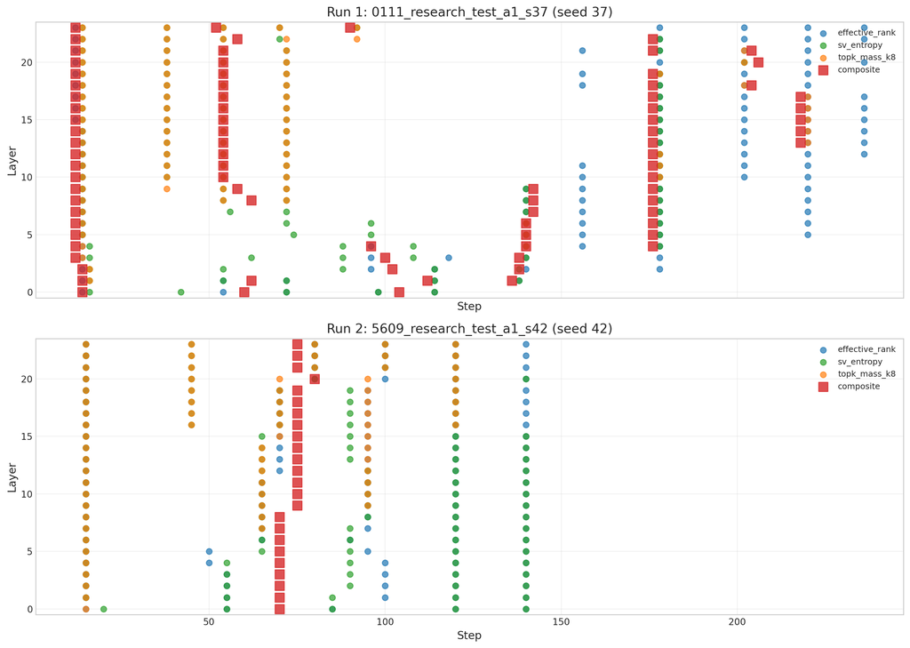

```python
# Plot raster for each run
n_runs = len(runs)
fig, axes = plt.subplots(n_runs, 1, figsize=(14, 5 * n_runs), sharex=True)
if n_runs == 1:
    axes = [axes]

for i, run in enumerate(runs):
    seed = run.meta.get('seed', '?')
    short_id = run.run_id[-25:] if len(run.run_id) > 25 else run.run_id
    plot_event_raster(run.events_df, f"Run {i+1}: {short_id} (seed {seed})", axes[i])

plt.tight_layout()
plt.show()
```

```python
# LLM Analysis: Raster Plots
if ENABLE_LLM_ANALYSIS:
    def get_layer_range(events_df):
        if events_df.empty or "layer" not in events_df.columns:
            return "N/A"
        return f"{events_df['layer'].min()}-{events_df['layer'].max()}"

    def get_step_range(events_df):
        if events_df.empty or "step" not in events_df.columns:
            return "N/A"
        return f"{events_df['step'].min()}-{events_df['step'].max()}"

    # Build run info for all runs
    run_infos = []
    for run in runs:
        run_infos.append({
            "run_id": run.run_id,
            "seed": run.meta.get("seed", "?"),
            "n_events": len(run.events_df),
            "layer_range": get_layer_range(run.events_df),
            "step_range": get_step_range(run.events_df),
        })

    # For N runs, we pass the first two to the existing function but provide context for all
    # Build a custom analysis for N runs
    if len(runs) == 2:
        raster_analysis = analyze_raster_plot(
            run_a_info=run_infos[0],
            run_b_info=run_infos[1],
            backend=LLM_BACKEND,
            model=LLM_MODEL,
        )
    else:
        # For N>2 runs, use a custom prompt with all run info
        from squiggle_analysis.llm_analysis.section_analyzer import _make_section_request

        section_prompt = """Analyze these event raster plots showing detected change points across layers and steps for multiple runs.

Consider:
- Are events clustered in specific layers or distributed across all runs?
- Are there temporal patterns (early burst, late clustering) consistent across runs?
- Do the runs show similar spatial patterns?
- Which runs are most similar/different to each other?
- Any obvious asymmetries between runs?"""

        runs_context = "\n".join([
            f"Run {i+1}: {info['run_id'][:30]} (seed={info['seed']})\n"
            f"  - Total events: {info['n_events']}\n"
            f"  - Layer range: {info['layer_range']}\n"
            f"  - Step range: {info['step_range']}"
            for i, info in enumerate(run_infos)
        ])

        raster_analysis = _make_section_request(
            "raster_plot_multi",
            section_prompt,
            runs_context,
            backend=LLM_BACKEND,
            model=LLM_MODEL,
        )

    display_analysis(raster_analysis, "Raster Plots")

    # Store for overall synthesis
    SECTION_ANALYSES.append({
        "section_name": "Raster Plots",
        "interpretation": raster_analysis.interpretation,
        "observations": raster_analysis.key_observations,
    })
```

🤖 LLM Analysis: Raster Plots

**Interpretation:** The raster plots reveal that events in Run A are more densely clustered across layers compared to Run B, suggesting a more active learning phase. Temporal patterns indicate an early burst of events in both runs, but Run A shows sustained activity through the later steps, while Run B experiences a notable drop-off after step 140.

**Key Observations:**

- Run A has 410 total events, indicating a higher frequency of detected change points compared to Run B's 336 events.

- Events in both runs are distributed across all layers (0-23), but Run A exhibits a more uniform distribution, while Run B shows clustering in the lower layers.

- Temporal analysis shows an early burst of events in both runs, but Run A maintains a more consistent event rate into the later steps, contrasting with the rapid decline in Run B.

**Questions Raised:**

- What specific factors contributed to the higher event count in Run A compared to Run B?

- Could the differences in event distribution across layers indicate variations in learning dynamics between the two runs?

## 3. Common Events Overlay

Show events that appear in both runs.

```python
# Find common events
common_events = find_common_events(runs, step_tolerance=STEP_TOLERANCE)
print(f"Found {len(common_events)} common events (strict matching, ±{STEP_TOLERANCE} steps)")

if not common_events.empty:
    display(common_events.head(20))
```

```
Found 71 common events (strict matching, ±5 steps)
```

|  | layer | metric | event_type | mean_step | std_step | min_step | max_step | mean_score | std_score | n_runs |
| --- | --- | --- | --- | --- | --- | --- | --- | --- | --- | --- |
| 0 | 23 | effective_rank | change_point | 13.5 | 1.5 | 12 | 15 | 17.869894 | 7.265248 | 2 |
| 1 | 18 | effective_rank | change_point | 13.5 | 1.5 | 12 | 15 | 17.252580 | 7.563175 | 2 |
| 2 | 20 | effective_rank | change_point | 13.5 | 1.5 | 12 | 15 | 17.584049 | 5.786174 | 2 |
| 3 | 17 | effective_rank | change_point | 13.5 | 1.5 | 12 | 15 | 17.797585 | 5.414747 | 2 |
| 4 | 22 | effective_rank | change_point | 13.5 | 1.5 | 12 | 15 | 16.299135 | 6.377308 | 2 |
| 5 | 21 | effective_rank | change_point | 13.5 | 1.5 | 12 | 15 | 14.967034 | 6.597802 | 2 |
| 6 | 19 | effective_rank | change_point | 13.5 | 1.5 | 12 | 15 | 14.687971 | 5.691022 | 2 |
| 7 | 16 | effective_rank | change_point | 13.5 | 1.5 | 12 | 15 | 14.782105 | 5.050339 | 2 |
| 8 | 15 | effective_rank | change_point | 13.5 | 1.5 | 12 | 15 | 13.711747 | 5.211759 | 2 |
| 9 | 14 | effective_rank | change_point | 14.5 | 0.5 | 14 | 15 | 13.603853 | 4.509641 | 2 |
| 10 | 13 | effective_rank | change_point | 14.5 | 0.5 | 14 | 15 | 13.158247 | 4.262413 | 2 |
| 11 | 12 | effective_rank | change_point | 14.5 | 0.5 | 14 | 15 | 12.072679 | 3.894332 | 2 |
| 12 | 11 | effective_rank | change_point | 14.5 | 0.5 | 14 | 15 | 10.758907 | 2.146324 | 2 |
| 13 | 10 | effective_rank | change_point | 14.5 | 0.5 | 14 | 15 | 10.632068 | 1.704088 | 2 |
| 14 | 8 | effective_rank | change_point | 14.5 | 0.5 | 14 | 15 | 10.910905 | 1.333977 | 2 |
| 15 | 7 | effective_rank | change_point | 14.5 | 0.5 | 14 | 15 | 11.138453 | 0.535500 | 2 |
| 16 | 9 | effective_rank | change_point | 14.5 | 0.5 | 14 | 15 | 9.897999 | 1.301061 | 2 |
| 17 | 6 | effective_rank | change_point | 14.5 | 0.5 | 14 | 15 | 9.472049 | 0.865450 | 2 |
| 18 | 1 | effective_rank | change_point | 14.5 | 0.5 | 14 | 15 | 8.425338 | 0.854276 | 2 |
| 19 | 5 | effective_rank | change_point | 14.5 | 0.5 | 14 | 15 | 9.921447 | 2.495272 | 2 |

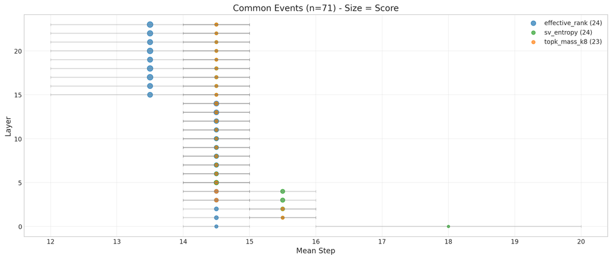

```python
fig, ax = plt.subplots(figsize=(14, 6))

if not common_events.empty:
    # Color by metric
    metric_colors = {
        "effective_rank": "#1f77b4",
        "sv_entropy": "#2ca02c",
        "topk_mass_k8": "#ff7f0e",
    }

    for metric, color in metric_colors.items():
        mask = common_events["metric"] == metric
        if mask.sum() > 0:
            ax.scatter(
                common_events.loc[mask, "mean_step"],
                common_events.loc[mask, "layer"],
                c=color,
                s=common_events.loc[mask, "mean_score"] * 5,  # Size by score
                alpha=0.7,
                label=f"{metric} ({mask.sum()})"
            )

    # Add error bars for step variance
    ax.errorbar(
        common_events["mean_step"],
        common_events["layer"],
        xerr=common_events["std_step"],
        fmt='none',
        ecolor='gray',
        alpha=0.3,
        capsize=2
    )

ax.set_xlabel("Mean Step", fontsize=12)
ax.set_ylabel("Layer", fontsize=12)
ax.set_title(f"Common Events (n={len(common_events)}) - Size = Score", fontsize=14)
ax.legend(loc="upper right")
ax.grid(True, alpha=0.3)
plt.tight_layout()
plt.show()
```

```python
# LLM Analysis: Common Events
if ENABLE_LLM_ANALYSIS:
    # Build summary of common events distribution
    common_summary = {}
    if not common_events.empty:
        if "layer" in common_events.columns:
            common_summary["layer_counts"] = common_events["layer"].value_counts().head(5).to_dict()
        if "metric" in common_events.columns:
            common_summary["metric_counts"] = common_events["metric"].value_counts().to_dict()

    total_events = sum(len(run.events_df) for run in runs)

    common_analysis = analyze_common_events(
        n_common=len(common_events),
        step_tolerance=STEP_TOLERANCE,
        common_events_summary=common_summary,
        run_a_total=len(runs[0].events_df),
        run_b_total=len(runs[1].events_df) if len(runs) > 1 else 0,
        backend=LLM_BACKEND,
        model=LLM_MODEL,
    )
    display_analysis(common_analysis, "Common Events")

    # Store for overall synthesis
    SECTION_ANALYSES.append({
        "section_name": "Common Events",
        "interpretation": common_analysis.interpretation,
        "observations": common_analysis.key_observations,
    })
```

🤖 LLM Analysis: Common Events

**Interpretation:** The common events between Run A and Run B represent only 10.5% of the total events, indicating a low level of reproducibility in the learning dynamics. Despite the total number of events being substantial, the limited overlap suggests that the runs may be influenced by different stochastic factors or training conditions.

**Key Observations:**

- A total of 71 common events were identified, which is a small fraction of the overall events (410 in Run A and 336 in Run B).

- The distribution of common events across layers is even, with 3 events each in layers 17, 18, 20, 22, and 23, indicating that no single layer dominates the overlap.

- The metrics contributing to common events are relatively balanced, with effective_rank and sv_entropy each contributing 24 events, suggesting that these metrics are critical in capturing shared dynamics.

**Questions Raised:**

- What specific factors might account for the low Jaccard similarity despite a significant number of events?

- Could adjusting the event detection parameters improve the overlap in future runs?